# Lab 4

Author

Van K Stewart

In this lab, we will be using the `dplyr` package to explore student evaluations of teaching data.

**You are expected to use functions from `dplyr` to do your data manipulation!**

# Part 1: GitHub Workflow

Now that you have the Lab 5 repository cloned, you need to make sure you can successfully push to GitHub. To do this you need to:

- Open the `lab-5-student.qmd` file (in the lower right hand corner).
- Change the `author` line at the top of the document (in the YAML) to your name.
- Save your file either by clicking on the blue floppy disk or with a shortcut (command / control + s).
- Click the “Git” tab in upper right pane
- Check the “Staged” box for the `lab-5-student.qmd` file (the file you changed)
- Click “Commit”
- In the box that opens, type a message in “Commit message”, such as “Added my name”.
- Click “Commit”.
- Click the green “Push” button to send your local changes to GitHub.

RStudio will display something like:

```
>>> /usr/bin/git push origin HEAD:refs/heads/main
To https://github.com/atheobold/introduction-to-quarto-allison-theobold.git
   3a2171f..6d58539  HEAD -> main
```

Now you are ready to go! Remember, as you are going through the lab I would strongly recommend rendering your HTML and committing your after **every** question!

# Part 2: Some Words of Advice

Part of learning to program is learning from a variety of resources. Thus, I expect you will use resources that you find on the internet. There is, however, an important balance between copying someone else’s code and *using their code to learn*.

Therefore, if you use external resources, I want to know about it.

- If you used Google, you are expected to “inform” me of any resources you used by **pasting the link to the resource in a code comment next to where you used that resource**.
- If you used ChatGPT, you are expected to “inform” me of the assistance you received by (1) indicating somewhere in the problem that you used ChatGPT (e.g., below the question prompt or as a code comment), and (2) downloading and including the `.txt` file containing your **entire** conversation with ChatGPT.

Additionally, you are permitted and encouraged to work with your peers as you complete lab assignments, but **you are expected to do your own work**. Copying from each other is cheating, and letting people copy from you is also cheating. Please don’t do either of those things.

## Setting Up Your Code Chunks

- The first chunk of this Quarto document should be used to *declare your libraries* (probably only `tidyverse` for now).
- The second chunk of your Quarto document should be to *load in your data*.

## Save Regularly, Render Often

- Be sure to **save** your work regularly.
- Be sure to **render** your file every so often, to check for errors and make sure it looks nice.
  - Make sure your Quarto document does not contain `View(dataset)` or `install.packages("package")`, both of these will prevent rendering.
  - Check your Quarto document for occasions when you looked at the data by typing the name of the data frame. Leaving these in means the whole dataset will print out and this looks unprofessional. **Remove these!**
  - If all else fails, you can set your execution options to `error: true`, which will allow the file to render even if errors are present.

# Part 3: Let’s Start Working with the Data!

## The Data

The `teacher_evals` dataset contains student evaluations of reaching (SET) collected from students at a University in Poland. There are SET surveys from students in all fields and all levels of study offered by the university.

The SET questionnaire that every student at this university completes is as follows:

> Evaluation survey of the teaching staff of University of Poland. Please complete the following evaluation form, which aims to assess the lecturer’s performance. Only one answer should be indicated for each question. The answers are coded in the following way: 5 - I strongly agree; 4 - I agree; 3 - Neutral; 2 - I don’t agree; 1 - I strongly don’t agree.

> Question 1: I learned a lot during the course.

> Question 2: I think that the knowledge acquired during the course is very useful.

> Question 3: The professor used activities to make the class more engaging.

> Question 4: If it was possible, I would enroll for a course conducted by this lecturer again.

> Question 5: The classes started on time.

> Question 6: The lecturer always used time efficiently.

> Question 7: The lecturer delivered the class content in an understandable and efficient way.

> Question 8: The lecturer was available when we had doubts.

> Question 9. The lecturer treated all students equally regardless of their race, background and ethnicity.

These data are from the end of the winter semester of the 2020-2021 academic year. In the period of data collection, all university classes were entirely online amid the COVID-19 pandemic. While expected learning outcomes were not changed, the online mode of study could have affected grading policies and could have implications for data.

**Average SET scores** were combined with many other variables, including:

1. **characteristics of the teacher** (degree, seniority, gender, SET scores in the past 6 semesters).
2. **characteristics of the course** (time of day, day of the week, course type, course breadth, class duration, class size).
3. **percentage of students providing SET feedback.**
4. **course grades** (mean, standard deviation, percentage failed for the current course and previous 6 semesters).

This rich dataset allows us to **investigate many of the biases in student evaluations of teaching** that have been reported in the literature and to formulate new hypotheses.

Before tackling the problems below, study the description of each variable included in the `teacher_evals_codebook.pdf`.

**1. Load the appropriate R packages for your analysis.**

```r
# code chunk for loading packages

library(tidyverse)
```

**2. Load in the `teacher_evals` data.**

```r
# code chunk for importing the data

teacherE <- read_csv("teacher_evals.csv")
```

### Data Inspection + Summary

**3. Provide a brief overview (~4 sentences) of the dataset.**

```r
#|label: explore-data

## view(teacherE)

glimpse(teacherE)
```

```
Rows: 8,015
Columns: 22
$ course_id               <chr> "0000-BHP", "0000-BHP", "0000-BHP", "0000-BHP"…
$ teacher_id              <dbl> 54655, 54655, 54655, 54655, 54655, 3432, 3432,…
$ question_no             <dbl> 901, 903, 904, 905, 907, 902, 903, 906, 909, 9…
$ no_participants         <dbl> 255, 255, 255, 255, 255, 998, 998, 998, 998, 1…
$ resp_share              <dbl> 0.21176471, 0.20784314, 0.21176471, 0.20784314…
$ SET_score_avg           <dbl> 4.222222, 3.679245, 3.740741, 3.301887, 3.6792…
$ stud_grade_avg          <dbl> 3.000000, 3.000000, 3.000000, 3.000000, 3.0000…
$ stud_grade_std          <dbl> 0.0000000, 0.0000000, 0.0000000, 0.0000000, 0.…
$ stud_grade_var_coef     <dbl> 0.0000000, 0.0000000, 0.0000000, 0.0000000, 0.…
$ percent_failed          <dbl> 0.000000000, 0.000000000, 0.000000000, 0.00000…
$ stud_grade_avg_cur      <dbl> 3.000000, 3.000000, 3.000000, 3.000000, 3.0000…
$ stud_grade_std_cur      <dbl> 0.0000000, 0.0000000, 0.0000000, 0.0000000, 0.…
$ stud_grade_var_coef_cur <dbl> 0.0000000, 0.0000000, 0.0000000, 0.0000000, 0.…
$ percent_failed_cur      <dbl> 0.000000000, 0.000000000, 0.000000000, 0.00000…
$ class_duration          <dbl> 0, 0, 0, 0, 0, 0, 0, 0, 0, 0, 0, 0, 0, 0, 0, 0…
$ weekday                 <chr> "Friday", "Friday", "Friday", "Friday", "Frida…
$ time_of_day             <chr> "<10", "<10", "<10", "<10", "<10", "14-18", "1…
$ SET_score_1sem          <dbl> 3.820000, 3.820000, 3.820000, 3.820000, 3.8200…
$ maximum_score           <dbl> 0, 0, 0, 0, 0, 0, 0, 0, 0, 0, 0, 0, 0, 0, 0, 0…
$ academic_degree         <chr> "no_dgr", "no_dgr", "no_dgr", "no_dgr", "no_dg…
$ seniority               <dbl> 4, 4, 4, 4, 4, 11, 11, 11, 11, 11, 11, 11, 11,…
$ gender                  <chr> "male", "male", "male", "male", "male", "male"…
```

```r
summary(teacherE)
```

```
  course_id           teacher_id      question_no  no_participants
 Length:8015        Min.   :  3432   Min.   :901   Min.   :   1.00
 Class :character   1st Qu.: 38606   1st Qu.:903   1st Qu.:  15.00
 Mode  :character   Median : 50752   Median :905   Median :  27.00
                    Mean   : 49964   Mean   :905   Mean   :  46.95
                    3rd Qu.: 66076   3rd Qu.:907   3rd Qu.:  50.00
                    Max.   :110292   Max.   :909   Max.   :1003.00
                                                   NA's   :34
   resp_share      SET_score_avg   stud_grade_avg  stud_grade_std
 Min.   :0.00348   Min.   :1.000   Min.   :2.375   Min.   :0.0000
 1st Qu.:0.06061   1st Qu.:4.000   1st Qu.:3.583   1st Qu.:0.6369
 Median :0.10000   Median :4.667   Median :4.015   Median :0.8562
 Mean   :0.14020   Mean   :4.392   Mean   :3.962   Mean   :0.8078
 3rd Qu.:0.16667   3rd Qu.:5.000   3rd Qu.:4.392   3rd Qu.:1.0100
 Max.   :1.00000   Max.   :5.000   Max.   :5.000   Max.   :1.7678
 NA's   :34                        NA's   :41      NA's   :41
 stud_grade_var_coef percent_failed    stud_grade_avg_cur stud_grade_std_cur
 Min.   :0.0000      Min.   :0.00000   Min.   :2.375      Min.   :0.0000
 1st Qu.:0.1483      1st Qu.:0.00000   1st Qu.:3.583      1st Qu.:0.5632
 Median :0.2150      Median :0.07692   Median :4.048      Median :0.8311
 Mean   :0.2120      Mean   :0.12490   Mean   :3.990      Mean   :0.7907
 3rd Qu.:0.2777      3rd Qu.:0.19048   3rd Qu.:4.450      3rd Qu.:1.0278
 Max.   :0.5439      Max.   :0.75000   Max.   :5.000      Max.   :1.7678
 NA's   :41          NA's   :41        NA's   :41         NA's   :41
 stud_grade_var_coef_cur percent_failed_cur class_duration    weekday
 Min.   :0.0000          Min.   :0.0000     Min.   :0.000   Length:8015
 1st Qu.:0.1325          1st Qu.:0.0000     1st Qu.:1.000   Class :character
 Median :0.2107          Median :0.0723     Median :2.000   Mode  :character
 Mean   :0.2073          Mean   :0.1274     Mean   :1.564
 3rd Qu.:0.2795          3rd Qu.:0.2000     3rd Qu.:2.000
 Max.   :0.5439          Max.   :0.7500     Max.   :3.000
 NA's   :41              NA's   :41         NA's   :914
 time_of_day        SET_score_1sem  maximum_score    academic_degree
 Length:8015        Min.   :1.220   Min.   :0.0000   Length:8015
 Class :character   1st Qu.:4.119   1st Qu.:0.0000   Class :character
 Mode  :character   Median :4.471   Median :0.0000   Mode  :character
                    Mean   :4.388   Mean   :0.4131
                    3rd Qu.:4.685   3rd Qu.:1.0000
                    Max.   :5.000   Max.   :1.0000
                    NA's   :697
   seniority         gender
 Min.   : 1.000   Length:8015
 1st Qu.: 2.000   Class :character
 Median : 6.000   Mode  :character
 Mean   : 5.496
 3rd Qu.: 8.000
 Max.   :11.000
```

> > Data consist of teacher ID, number of questions, number of participants, teachers score, and various information on students’ academics.

**4. What is the unit of observation (i.e. a single row in the dataset) identified by?**

> > There is a teacher ID number, along with a course ID number.

**5. Use *one* `dplyr` pipeline to clean the data by:**

- **renaming the `gender` variable `sex`**
- **removing all courses with fewer than 10 respondents**
- **changing data types in whichever way you see fit (e.g., is the instructor ID really a numeric data type?)**
- **only keeping the columns we will use – `course_id`, `teacher_id`, `question_no`, `no_participants`, `resp_share`, `SET_score_avg`, `percent_failed_cur`, `academic_degree`, `seniority`, and `sex`**

**Assign your cleaned data to a new variable named `teacher_evals_clean` –- use these data going forward. Save the data as `teacher_evals_clean.csv` in the `data-clean` folder.**

```r
# code chunk for Q4


## load the data
teacher_evals_clean <- teacherE|>

  ## Rename the 'sex' column to gender
  rename( sex = gender )|>

  ## Removes courses with fewer then 10 ppl
  filter(no_participants >= 10)|>

  ## Sets teacher id to numeric
  mutate(teacher_id = as.numeric(teacher_id))|>

  ## Selects for the columns we want
  select(course_id, teacher_id, question_no, no_participants, resp_share,
         SET_score_avg, percent_failed_cur, academic_degree, seniority, sex)|>

  ## Saves the csv
  write_csv("TeacherEC.csv")

## Checking my work
view(teacher_evals_clean)
```

**6. How many unique instructors and unique courses are present in the cleaned dataset?**

```r
# code chunk for Q5

teacher_evals_clean|>
distinct( course_id )
```

```
# A tibble: 939 × 1
   course_id
   <chr>
 1 0000-BHP
 2 0000-BW-NP
 3 0000-BW-SP
 4 0000-IIC
 5 0000-IM-SE
 6 0000-Library
 7 0000-OSH
 8 0000-PE
 9 0000-SEM-NP
10 0000-SEM-SE
# ℹ 929 more rows
```

```r
teacher_evals_clean|>
distinct( teacher_id )
```

```
# A tibble: 297 × 1
   teacher_id
        <dbl>
 1      54655
 2       3432
 3       3773
 4       4299
 5       3598
 6      75923
 7       3485
 8      38379
 9      40937
10      43908
# ℹ 287 more rows
```

> > There is 939 unique course IDs, and 297 teacher IDs.

**7. One teacher-course combination has some missing values, coded as `NA`. Which instructor has these missing values? Which course? What variable are the missing values in?**

```r
# code chunk for Q6


print(teacher_evals_clean|>

  ## checks across all columns for NA values.
    ## got the idea for this from here: https://stackoverflow.com/questions/66572756/checking-all-columns-in-data-frame-for-missing-values-in-r
  filter(if_any(everything(), is.na)))
```

```
# A tibble: 7 × 10
  course_id   teacher_id question_no no_participants resp_share SET_score_avg
  <chr>            <dbl>       <dbl>           <dbl>      <dbl>         <dbl>
1 PAB3SE004PA      56347         901              32     0.0312             5
2 PAB3SE004PA      56347         902              32     0.0312             5
3 PAB3SE004PA      56347         903              32     0.0312             4
4 PAB3SE004PA      56347         905              32     0.0312             4
5 PAB3SE004PA      56347         906              32     0.0312             3
6 PAB3SE004PA      56347         907              32     0.0312             3
7 PAB3SE004PA      56347         908              32     0.0312             5
# ℹ 4 more variables: percent_failed_cur <dbl>, academic_degree <chr>,
#   seniority <dbl>, sex <chr>
```

> > teacher number 56347, they are missing `percent_failed_cur` column.

**8. What are the demographics of the instructors in this study? Investigate the variables `academic_degree`, `seniority`, and `sex` and summarize your findings in ~3 complete sentences.**

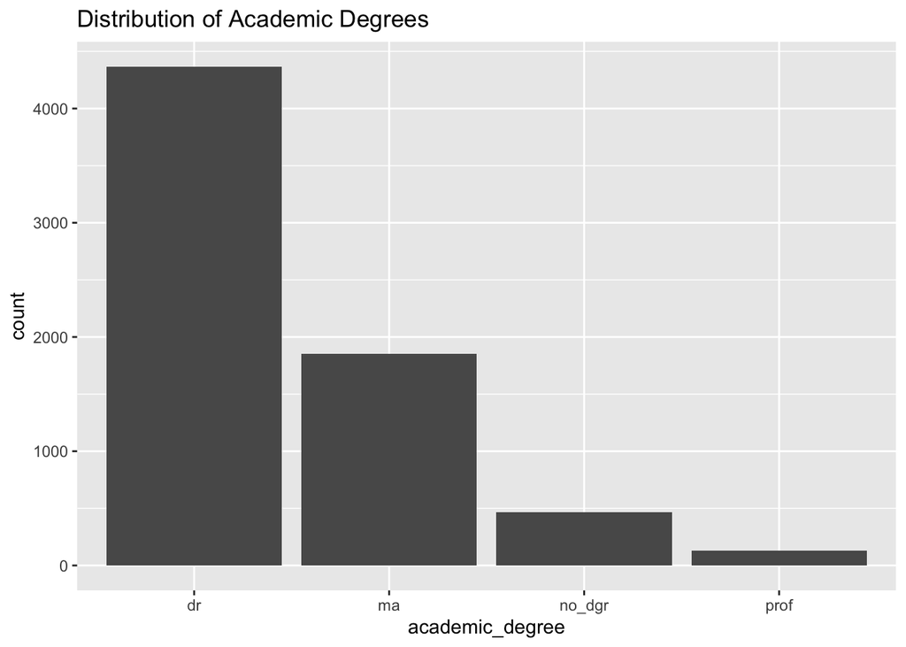

```r
# code chunk for Q7

## Determine distribution of academic_degree
ggplot(teacher_evals_clean, aes(x = academic_degree)) +
  geom_bar() +
  labs(title = "Distribution of Academic Degrees")
```

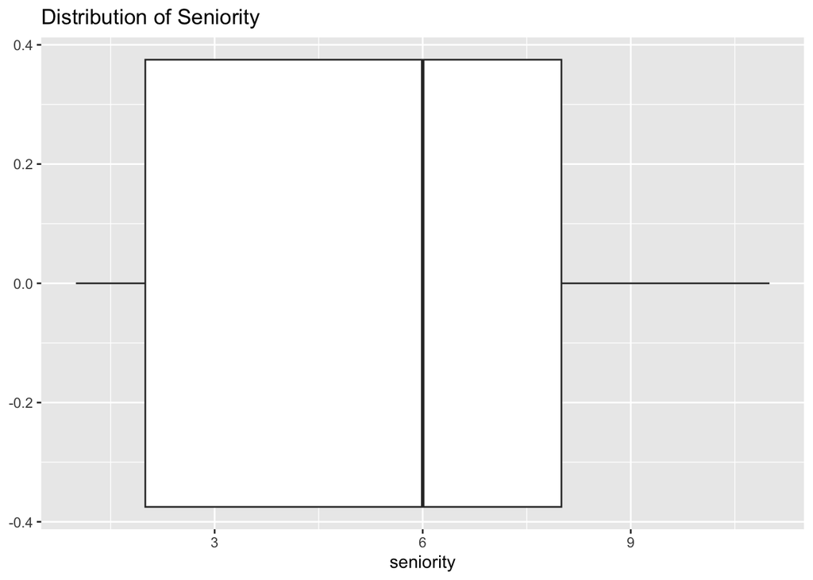

```r
## Determine distribution of seniority
ggplot(teacher_evals_clean, aes(x = seniority)) +
  geom_boxplot() +
  labs(title = "Distribution of Seniority")
```

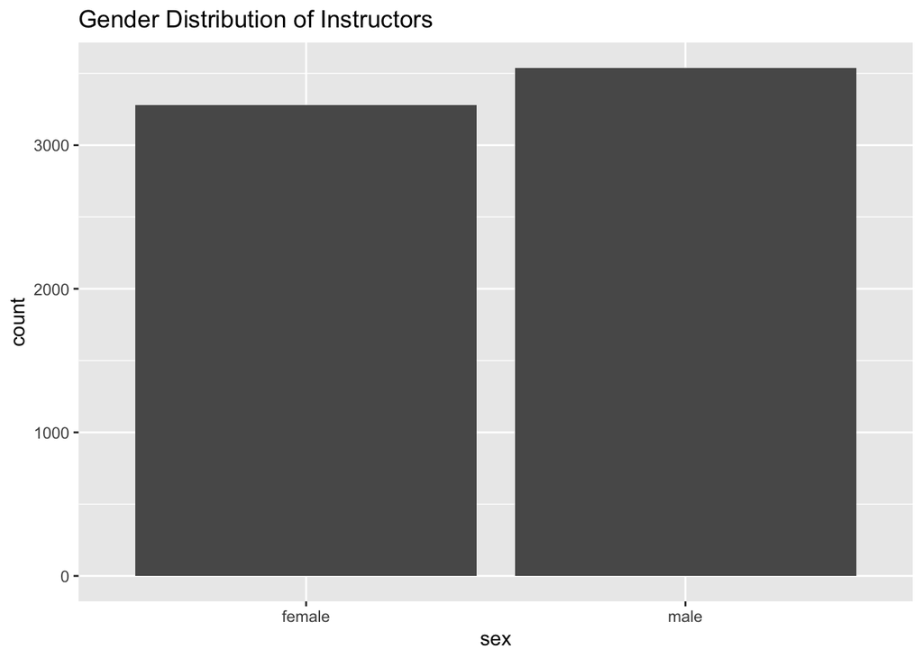

```r
## Determine distribution of sex
ggplot(teacher_evals_clean, aes(x = sex)) +
  geom_bar() +
  labs(title = "Gender Distribution of Instructors")
```

**9. Each course seems to have used a different subset of the nine evaluation questions. How many teacher-course combinations asked all nine questions?**

```r
# code chunk for Q8

teacher_evals_clean |>

  ## counts how many times each teacher and course ID exist in the dataset
  count(teacher_id, course_id)|>

  ## filters out how many have more than nine responses
  filter(n == 9 )
```

```
# A tibble: 49 × 3
   teacher_id course_id            n
        <dbl> <chr>            <int>
 1       3485 MNB5NP04MN-Z20-w     9
 2       3503 FAB1NP-SJO-A         9
 3       3521 CII3SP12CI-Z17       9
 4       3614 FAB1NP-SJO-A         9
 5       3614 MN-B1SP-SJO-A        9
 6       3662 CII2SE02CI-L19       9
 7       4299 IRB5SE02IR-Z20       9
 8      37025 ECB3SE01EC-Z20       9
 9      37035 MNB1NP-SJO-A         9
10      37068 IRB5SP04-PDW         9
# ℹ 39 more rows
```

> > 49 combinations asked all nine questions.

## Rate my Professor

**10. Which instructors had the highest and lowest average rating for Question 1 (I learnt a lot during the course.) across all their courses?**

```r
# code chunk for Q9
 teacher_evals_clean|>
  group_by(teacher_id)|>
  arrange(SET_score_avg)
```

```
# A tibble: 6,817 × 10
# Groups:   teacher_id [297]
   course_id     teacher_id question_no no_participants resp_share SET_score_avg
   <chr>              <dbl>       <dbl>           <dbl>      <dbl>         <dbl>
 1 CII3NP07-PDW        3477         905              53     0.0577             1
 2 CII3SE08-PDW      100132         901              57     0.0175             1
 3 CII5NP05CI-Z…      44338         902              31     0.0645             1
 4 CII5NP05CI-Z…      44338         903              31     0.0645             1
 5 CII5NP05CI-Z…      44338         904              31     0.0645             1
 6 CII5NP05CI-Z…      44338         907              31     0.0645             1
 7 CII5NP05CI-Z…      44338         908              31     0.0645             1
 8 CII5NP05CI-Z…      44338         909              31     0.0645             1
 9 CII7NP02CI-Z…      54662         903              32     0.0312             1
10 CII7NP02CI-Z…      54662         905              32     0.0312             1
# ℹ 6,807 more rows
# ℹ 4 more variables: percent_failed_cur <dbl>, academic_degree <chr>,
#   seniority <dbl>, sex <chr>
```

**11. Which instructors with one year of experience had the highest and lowest average percentage of students failing in the current semester across all their courses?**

```r
# code chunk for Q10


##
teacher_evals_clean|>

  ## Selects for teachers with one year experience
  filter( seniority == 1)|>

  ## Groups by teacher ID
  group_by( teacher_id )|>

  ## Sorts percent failed
  arrange(percent_failed_cur)
```

```
# A tibble: 410 × 10
# Groups:   teacher_id [33]
   course_id     teacher_id question_no no_participants resp_share SET_score_avg
   <chr>              <dbl>       <dbl>           <dbl>      <dbl>         <dbl>
 1 CII7SE06CI-Z…      98650         901              16     0.0625          5
 2 CII7SE06CI-Z…      98650         902              16     0.0625          5
 3 CII7SE06CI-Z…      98650         903              16     0.0625          5
 4 CII7SE06CI-Z…      98650         906              16     0.0625          5
 5 CII7SE06CI-Z…      98650         908              16     0.0625          5
 6 CII7SE06CI-Z…      98650         909              16     0.0625          5
 7 IRB1SP01IR-Z…     106126         903              52     0.0577          4.33
 8 IRB1SP01IR-Z…     106126         904              52     0.0577          4.33
 9 IRB1SP01IR-Z…     106126         905              52     0.0577          3.67
10 IRB1SP01IR-Z…     106126         906              52     0.0577          4.33
# ℹ 400 more rows
# ℹ 4 more variables: percent_failed_cur <dbl>, academic_degree <chr>,
#   seniority <dbl>, sex <chr>
```

**12. Which female instructors with either a doctorate or professional degree had the highest and lowest average percent of students responding to the evaluation across all their courses?**

```r
# code chunk for Q11

teacher_evals_clean|>

  filter( sex == "female" , academic_degree == c("dr", "prof"))|>

    ## Groups by teacher ID
  group_by( teacher_id )|>

  ## Sorts percent failed
  arrange(percent_failed_cur)
```

```
# A tibble: 1,070 × 10
# Groups:   teacher_id [74]
   course_id   teacher_id question_no no_participants resp_share SET_score_avg
   <chr>            <dbl>       <dbl>           <dbl>      <dbl>         <dbl>
 1 0000-SEM-NP       3485         902              21     0.0476          4
 2 0000-SEM-NP       3485         905              21     0.0476          4
 3 0000-SEM-NP       3485         909              21     0.0476          4
 4 0000-SEM-NP      38379         903              20     0.1             4.5
 5 0000-SEM-NP      38379         905              20     0.1             4.5
 6 0000-SEM-NP      38379         908              20     0.1             4.5
 7 AAB3NP007        66283         901              39     0.154           5
 8 AAB3NP007        66283         905              39     0.154           4.5
 9 AAB3NP007        66283         907              39     0.154           4.83
10 AAB5NP-S         66283         901              14     0.214           5
# ℹ 1,060 more rows
# ℹ 4 more variables: percent_failed_cur <dbl>, academic_degree <chr>,
#   seniority <dbl>, sex <chr>
```